# Pratical Machine Learning Course Project

A. Mopa

30 janvier 2016

## Synopsis

Using data from accelerometers on the belt, forearm, arm, and dumbell of 6 participants, we have built a machine learning model to predict the manner in which the participants was performing activities.

## Reading datasets from web.

The data for this project come from this source: http://groupware.les.inf.puc-rio.br/har

```r
trainURL <- "https://d396qusza40orc.cloudfront.net/predmachlearn/pml-training.csv"
testURL <- "https://d396qusza40orc.cloudfront.net/predmachlearn/pml-testing.csv"
trainfile <- "pml-training.csv"
testfile <- "pml-testing.csv"
if (!file.exists(trainfile)) {
    download.file(trainURL, destfile = trainfile)
}
train <- read.table('pml-training.csv', header = TRUE, sep = ',', na.strings=c("NA", "#DIV/0!"))

if (!file.exists(testfile)) {
    download.file(testURL, destfile = testfile)
}
test <- read.table('pml-testing.csv', header = TRUE, sep = ',', na.strings=c("NA", "#DIV/0!"))
```

## Features selection

```r
nonatrain<- train[, apply(train, 2, function(x) !any(is.na(x)))] ## Selecting column without any NA value.

## Selecting predictor column  variables: Belt, arm, dumbbell, and forearm variables  are the selected predictor candidates
is.selectedcol <- grepl("belt|[^(fore)]arm|dumbbell|forearm", names(nonatrain)) ## creata a boolean vector
includedtest.col <- names(nonatrain)[is.selectedcol] ## Selecting column name with the boolean vector
included.col <- c("classe",includedtest.col)
training <- nonatrain[, included.col] ## The final trainning dataset
```

After this transformation, we have a dataset with 19622 observations, 1 outcome variable (“classe”) and 52 predictors variables.

```r
dim(training)
```

```
## [1] 19622    53
```

## Building a random forests model

The initial training dataset is partitioned into a smaller training dataset (*traindata*) and a validation dataset (*holdoutdata*)

```r
inTrain <- createDataPartition(y=training$classe, p=0.7, list=FALSE)
traindata <- training[inTrain,]
holdoutdata <- training[-inTrain,]
```

## Random forests and cross validation

In this section we apply random forests to the *traindata*, using the randomForest package in R. Here some motivation of random forests choice:

1. In random forests, there is no need for cross-validation or a separate test set to get an unbiased estimate of the test set error. It is estimated internally, during the run.
2. Random forests perform well on problem with non-linearity.
3. Random forest can be used on data with an extremely large number of features or examples
4. Random forest can help select only the most important features
5. Althougth Random forest may overfit a training data set, nevertheless, it has been shown that classifier variance does not grow with the number of trees used.

```r
set.seed(1234) #Set the pseudo-random seed to a known value to try and make estimation repeatable
 modfit <- randomForest(classe ~., data=traindata, importance=T, type="class")

 save(modfit,file="modfit.RData")

load("modfit.RData")
modfit
```

```
##
## Call:
##  randomForest(formula = classe ~ ., data = traindata, importance = T,      type = "class")
##                Type of random forest: classification
##                      Number of trees: 500
## No. of variables tried at each split: 7
##
##         OOB estimate of  error rate: 0.53%
## Confusion matrix:
##      A    B    C    D    E  class.error
## A 3904    1    1    0    0 0.0005120328
## B   15 2639    4    0    0 0.0071482318
## C    0   15 2378    3    0 0.0075125209
## D    0    0   24 2227    1 0.0111012433
## E    0    0    2    7 2516 0.0035643564
```

We have got an OOB estimate of error rate of 0.53% showing that the good quality of the model.

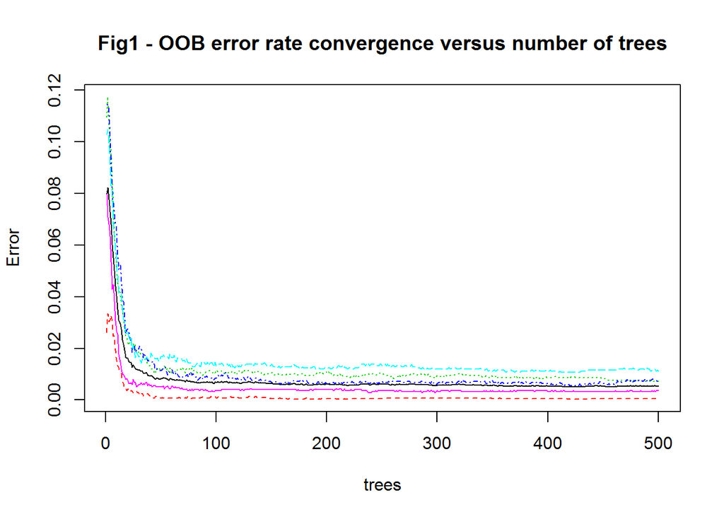

```r
plot(modfit, main = "Fig1 - OOB error rate convergence versus number of trees" )  # plotting the final model
```

By default, the randomForest() function creates an ensemble of 500 trees. In the final model plot (Fig1), we can see that the overall error converge at around 100 trees. So it is possible to speed up the model by tuning the number of trees.

## Checking the importance variables

```r
varImpo <- varImp(modfit)  # Calling importance() on the model
varImpo[1:10, ] # displaying the 10 first important variables
```

```
##                         A        B        C        D        E
## roll_belt        37.98931 45.56046 46.16085 45.07637 40.57446
## pitch_belt       30.64335 50.82037 38.70846 34.00090 32.87332
## yaw_belt         47.21192 44.26273 41.97311 46.51440 32.20844
## total_accel_belt 13.89558 18.56517 15.05493 14.33019 15.31680
## gyros_belt_x     18.43427 17.81928 20.11369 14.60887 17.00508
## gyros_belt_y     11.53237 15.92477 17.66050 15.70230 18.78602
## gyros_belt_z     21.15731 27.53031 25.41815 22.89305 26.90949
## accel_belt_x     14.81845 19.60116 17.31018 14.58495 16.28031
## accel_belt_y     12.35940 15.77824 13.23822 15.64020 14.05993
## accel_belt_z     20.46870 26.44766 26.94494 24.02653 20.92291
```

In the following figures Fig2 and Fig3, we have created two representation of the top 10 variables categorized by importance. Fig2 display the top 10 predictors Importance accuracy and Fig3 display the top 10 predictors Gini Importance.

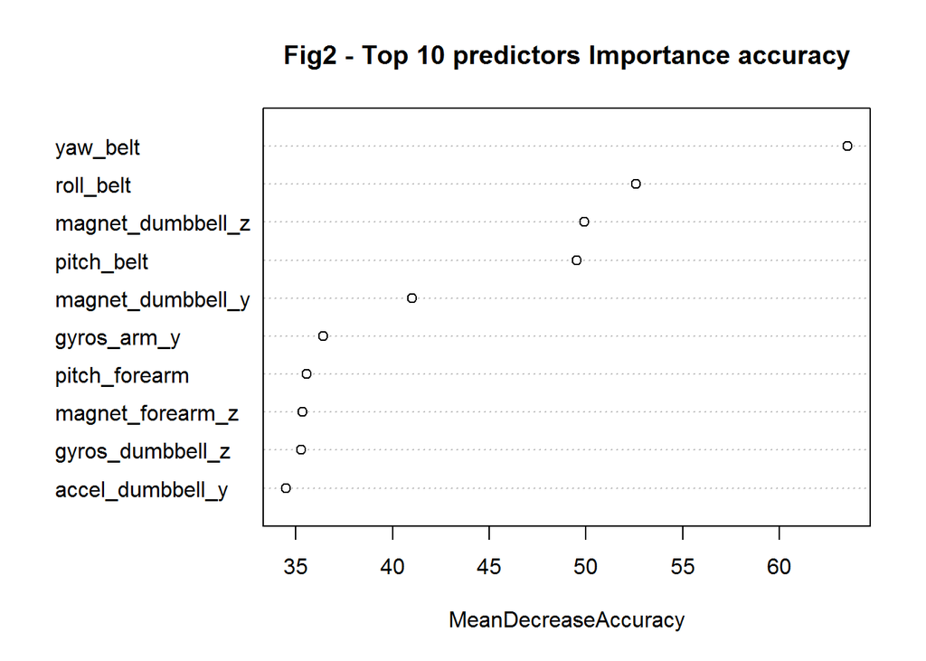

```r
 # Plot the   variable importance as measured by accuracy change
varImpPlot(modfit, type=1, n.var=10, scale=T, main="Fig2 - Top 10 predictors Importance accuracy")
```

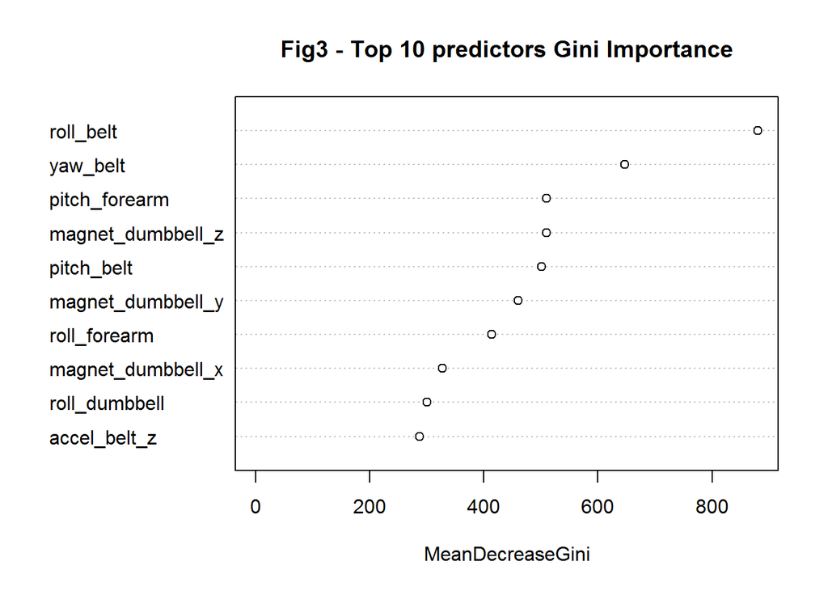

```r
varImpPlot(modfit, type=2, n.var=10, scale=T, main="Fig3 - Top 10 predictors Gini Importance")
```

## Holdout validation : expected out of sample error

Predicting the out of sample error using the hold out dataset (*holdoutdata*) containing 30% of the initial training dataset.

```r
predval <- predict(modfit,newdata=holdoutdata)  ### getting the values predicted by the model
missClass = function(values, prediction) {
    sum(prediction != values)/length(values)
}
errRate = missClass(holdoutdata$classe, predval)
errRate
```

```
## [1] 0.004587935
```

Based on the missclassificaiton rate on the validation dataset, the expected out of sample error is 0.46%.

## Using the model to make prediction on the test dataset

Using Our model, we have got 100% of the answer right.

```r
testdata <- test[,includedtest.col]  ## Selecting column name with the boolean vector
predtest <- predict(modfit,newdata=testdata)  ## getting the values predicted by the model
predtest
```

```
##  1  2  3  4  5  6  7  8  9 10 11 12 13 14 15 16 17 18 19 20
##  B  A  B  A  A  E  D  B  A  A  B  C  B  A  E  E  A  B  B  B
## Levels: A B C D E
```

## Conclusions

The final model plot (Fig1), show that the overall error converge at around 100 trees. So it is possible to speed up the model used here by tuning the number of trees.